# Zadanie domowe - EDA Danych dotyczących Irysów

- Twoim zadaniem jest wykonanie analizy danych zawartych w załączonym pliku CSV (`25__iris.csv`).
- Plik znajduje się pod video. Pamiętaj, żeby wrzucić plik do tego samego folderu, w którym znajduje się ten notebook.
- Wykorzystaj nowo nabytą wiedzę z biblioteki `Pandas`
- Jeżeli jest taka konieczność posiłkuj się [code explainerem](https://codeexplainer.imprv.ai/) lub / i [data chatterem](https://datachatter.imprv.ai/) (który również te dane ma dostępne).
- Prześlij na discordzie notebook z rozwiązaniem (`#modul-4-zad1`)
- Pamiętaj:
1. Nie spiesz się
2. Potraktuj zadanie domowe jak prawdziwy projekt
3. Dodawaj opisy, obserwacje, wnioski
4. Dodaj wizualizacje
5. Dodaj konkluzję i wnioski końcowe

Powodzenia!!! I mega zabawy!

## O Danych

Zbiór danych zawiera informacje o trzech gatunkach irysów: Iris setosa, Iris versicolor, i Iris virginica.

Dane obejmują pomiary czterech cech: długość i szerokość działki kielicha oraz długość i szerokość płatka.

Każdy wiersz w zbiorze danych reprezentuje pojedynczy kwiat, a wartości pomiarów są podane w centymetrach.

Zbiór składa się z 150 próbek, po 50 dla każdego gatunku, i jest szeroko stosowany jako podstawowy zbiór danych do testowania algorytmów klasyfikacji oraz w nauce o danych i uczeniu maszynowym.

Kolumny:

- **długość kielicha (sepal length)** - Długość kielicha w cm
- **szerokość kielicha (sepal width)** - Szerokość kielicha w cm
- **długość płatka (petal length)** - Długość płatka w cm
- **szerokość płatka (petal width)** - Szerokość płatka w cm
- **klasa (class)** - Klasa irysa (setosa, versicolor, virginica)

# CEL ANALIZY :

### Sprawdzenie spójności parametrów wewnątrz klas gatunkowych, oraz porównanie 3 gatunków Irysa wg dostępnych parametrów

```python
import pandas as pd
import random
import matplotlib.pyplot as plt
import numpy as np
import seaborn as sns
```

```python
import pandas as pd
import seaborn as sns
import matplotlib as mpl

print("pandas:", pd.__version__)
print("seaborn:", sns.__version__)
print("matplotlib:", mpl.__version__)
```

```
pandas: 2.1.4
seaborn: 0.13.2
matplotlib: 3.7.2
```

```python
df = pd.read_csv('25__iris.csv', sep=",")
df
```

|  | długość kielicha (sepal length) | szerokość kielicha (sepal width) | długość płatka (petal length) | szerokość płatka (petal width) | klasa (class) |
| --- | --- | --- | --- | --- | --- |
| 0 | 5.1 | 3.5 | 1.4 | 0.2 | Iris-setosa |
| 1 | 4.9 | 3.0 | 1.4 | 0.2 | Iris-setosa |
| 2 | 4.7 | 3.2 | 1.3 | 0.2 | Iris-setosa |
| 3 | 4.6 | 3.1 | 1.5 | 0.2 | Iris-setosa |
| 4 | 5.0 | 3.6 | 1.4 | 0.2 | Iris-setosa |
| ... | ... | ... | ... | ... | ... |
| 145 | 6.7 | 3.0 | 5.2 | 2.3 | Iris-virginica |
| 146 | 6.3 | 2.5 | 5.0 | 1.9 | Iris-virginica |
| 147 | 6.5 | 3.0 | 5.2 | 2.0 | Iris-virginica |
| 148 | 6.2 | 3.4 | 5.4 | 2.3 | Iris-virginica |
| 149 | 5.9 | 3.0 | 5.1 | 1.8 | Iris-virginica |

150 rows × 5 columns

# 1. Ogólny Przegląd Danych

```python
# Zmiana nazwy kolumn na wyłącznie polskojęzyczne dla skompaktowania tabeli

df.columns = ['dlugosc_kielicha', 'szerokosc_kielicha', 'dlugosc_platka', 'szerokosc_platka', 'klasa']
df
```

|  | dlugosc_kielicha | szerokosc_kielicha | dlugosc_platka | szerokosc_platka | klasa |
| --- | --- | --- | --- | --- | --- |
| 0 | 5.1 | 3.5 | 1.4 | 0.2 | Iris-setosa |
| 1 | 4.9 | 3.0 | 1.4 | 0.2 | Iris-setosa |
| 2 | 4.7 | 3.2 | 1.3 | 0.2 | Iris-setosa |
| 3 | 4.6 | 3.1 | 1.5 | 0.2 | Iris-setosa |
| 4 | 5.0 | 3.6 | 1.4 | 0.2 | Iris-setosa |
| ... | ... | ... | ... | ... | ... |
| 145 | 6.7 | 3.0 | 5.2 | 2.3 | Iris-virginica |
| 146 | 6.3 | 2.5 | 5.0 | 1.9 | Iris-virginica |
| 147 | 6.5 | 3.0 | 5.2 | 2.0 | Iris-virginica |
| 148 | 6.2 | 3.4 | 5.4 | 2.3 | Iris-virginica |
| 149 | 5.9 | 3.0 | 5.1 | 1.8 | Iris-virginica |

150 rows × 5 columns

```python
# Zmiana kolejności kolumn dla lepszego odczytu

df = df.iloc[:, [4, 0, 1, 2, 3]]
df
```

|  | klasa | dlugosc_kielicha | szerokosc_kielicha | dlugosc_platka | szerokosc_platka |
| --- | --- | --- | --- | --- | --- |
| 0 | Iris-setosa | 5.1 | 3.5 | 1.4 | 0.2 |
| 1 | Iris-setosa | 4.9 | 3.0 | 1.4 | 0.2 |
| 2 | Iris-setosa | 4.7 | 3.2 | 1.3 | 0.2 |
| 3 | Iris-setosa | 4.6 | 3.1 | 1.5 | 0.2 |
| 4 | Iris-setosa | 5.0 | 3.6 | 1.4 | 0.2 |
| ... | ... | ... | ... | ... | ... |
| 145 | Iris-virginica | 6.7 | 3.0 | 5.2 | 2.3 |
| 146 | Iris-virginica | 6.3 | 2.5 | 5.0 | 1.9 |
| 147 | Iris-virginica | 6.5 | 3.0 | 5.2 | 2.0 |
| 148 | Iris-virginica | 6.2 | 3.4 | 5.4 | 2.3 |
| 149 | Iris-virginica | 5.9 | 3.0 | 5.1 | 1.8 |

150 rows × 5 columns

```python
# Sprawdzenie informacji ogólnych o DATA FRAME

df.info()
```

```
<class 'pandas.core.frame.DataFrame'>
RangeIndex: 150 entries, 0 to 149
Data columns (total 5 columns):
 #   Column              Non-Null Count  Dtype
---  ------              --------------  -----
 0   klasa               150 non-null    object
 1   dlugosc_kielicha    150 non-null    float64
 2   szerokosc_kielicha  150 non-null    float64
 3   dlugosc_platka      150 non-null    float64
 4   szerokosc_platka    150 non-null    float64
dtypes: float64(4), object(1)
memory usage: 6.0+ KB
```

```python
# Sprawdzenie liczby rekordów w  KLASACH (class)

df['klasa'].value_counts()
```

```
klasa
Iris-setosa        50
Iris-versicolor    50
Iris-virginica     50
Name: count, dtype: int64
```

```python
# Sprawdzenie wartości unikalnych

df.nunique()
```

```
klasa                  3
dlugosc_kielicha      35
szerokosc_kielicha    23
dlugosc_platka        43
szerokosc_platka      22
dtype: int64
```

```python
# Pokazanie 15 losowych wierszy

df.sample(15)
```

|  | klasa | dlugosc_kielicha | szerokosc_kielicha | dlugosc_platka | szerokosc_platka |
| --- | --- | --- | --- | --- | --- |
| 60 | Iris-versicolor | 5.0 | 2.0 | 3.5 | 1.0 |
| 68 | Iris-versicolor | 6.2 | 2.2 | 4.5 | 1.5 |
| 5 | Iris-setosa | 5.4 | 3.9 | 1.7 | 0.4 |
| 111 | Iris-virginica | 6.4 | 2.7 | 5.3 | 1.9 |
| 86 | Iris-versicolor | 6.7 | 3.1 | 4.7 | 1.5 |
| 17 | Iris-setosa | 5.1 | 3.5 | 1.4 | 0.3 |
| 95 | Iris-versicolor | 5.7 | 3.0 | 4.2 | 1.2 |
| 142 | Iris-virginica | 5.8 | 2.7 | 5.1 | 1.9 |
| 24 | Iris-setosa | 4.8 | 3.4 | 1.9 | 0.2 |
| 21 | Iris-setosa | 5.1 | 3.7 | 1.5 | 0.4 |
| 125 | Iris-virginica | 7.2 | 3.2 | 6.0 | 1.8 |
| 118 | Iris-virginica | 7.7 | 2.6 | 6.9 | 2.3 |
| 105 | Iris-virginica | 7.6 | 3.0 | 6.6 | 2.1 |
| 148 | Iris-virginica | 6.2 | 3.4 | 5.4 | 2.3 |
| 49 | Iris-setosa | 5.0 | 3.3 | 1.4 | 0.2 |

```python
# Wyświetlenie podstawowych statystyk dla całości danych

df.describe()
```

|  | dlugosc_kielicha | szerokosc_kielicha | dlugosc_platka | szerokosc_platka |
| --- | --- | --- | --- | --- |
| count | 150.000000 | 150.000000 | 150.000000 | 150.000000 |
| mean | 5.843333 | 3.054000 | 3.758667 | 1.198667 |
| std | 0.828066 | 0.433594 | 1.764420 | 0.763161 |
| min | 4.300000 | 2.000000 | 1.000000 | 0.100000 |
| 25% | 5.100000 | 2.800000 | 1.600000 | 0.300000 |
| 50% | 5.800000 | 3.000000 | 4.350000 | 1.300000 |
| 75% | 6.400000 | 3.300000 | 5.100000 | 1.800000 |
| max | 7.900000 | 4.400000 | 6.900000 | 2.500000 |

```python
# Wyświetlenie podstawowych stastystyk dla każdej klasy Irysów

df.groupby('klasa').describe().T
```

|  | klasa | Iris-setosa | Iris-versicolor | Iris-virginica |
| --- | --- | --- | --- | --- |
| dlugosc_kielicha | count | 50.000000 | 50.000000 | 50.000000 |
|  | mean | 5.006000 | 5.936000 | 6.588000 |
|  | std | 0.352490 | 0.516171 | 0.635880 |
|  | min | 4.300000 | 4.900000 | 4.900000 |
|  | 25% | 4.800000 | 5.600000 | 6.225000 |
|  | 50% | 5.000000 | 5.900000 | 6.500000 |
|  | 75% | 5.200000 | 6.300000 | 6.900000 |
|  | max | 5.800000 | 7.000000 | 7.900000 |
| szerokosc_kielicha | count | 50.000000 | 50.000000 | 50.000000 |
|  | mean | 3.418000 | 2.770000 | 2.974000 |
|  | std | 0.381024 | 0.313798 | 0.322497 |
|  | min | 2.300000 | 2.000000 | 2.200000 |
|  | 25% | 3.125000 | 2.525000 | 2.800000 |
|  | 50% | 3.400000 | 2.800000 | 3.000000 |
|  | 75% | 3.675000 | 3.000000 | 3.175000 |
|  | max | 4.400000 | 3.400000 | 3.800000 |
| dlugosc_platka | count | 50.000000 | 50.000000 | 50.000000 |
|  | mean | 1.464000 | 4.260000 | 5.552000 |
|  | std | 0.173511 | 0.469911 | 0.551895 |
|  | min | 1.000000 | 3.000000 | 4.500000 |
|  | 25% | 1.400000 | 4.000000 | 5.100000 |
|  | 50% | 1.500000 | 4.350000 | 5.550000 |
|  | 75% | 1.575000 | 4.600000 | 5.875000 |
|  | max | 1.900000 | 5.100000 | 6.900000 |
| szerokosc_platka | count | 50.000000 | 50.000000 | 50.000000 |
|  | mean | 0.244000 | 1.326000 | 2.026000 |
|  | std | 0.107210 | 0.197753 | 0.274650 |
|  | min | 0.100000 | 1.000000 | 1.400000 |
|  | 25% | 0.200000 | 1.200000 | 1.800000 |
|  | 50% | 0.200000 | 1.300000 | 2.000000 |
|  | 75% | 0.300000 | 1.500000 | 2.300000 |
|  | max | 0.600000 | 1.800000 | 2.500000 |

```python
summary = df.groupby('klasa').mean().round(2)
summary
```

| klasa | dlugosc_kielicha | szerokosc_kielicha | dlugosc_platka | szerokosc_platka |
| --- | --- | --- | --- | --- |
| Iris-setosa | 5.01 | 3.42 | 1.46 | 0.24 |
| Iris-versicolor | 5.94 | 2.77 | 4.26 | 1.33 |
| Iris-virginica | 6.59 | 2.97 | 5.55 | 2.03 |

# 2. Kompletność i Jakość Danych

```python
# Dublikaty

df[df.duplicated()]
```

|  | klasa | dlugosc_kielicha | szerokosc_kielicha | dlugosc_platka | szerokosc_platka |
| --- | --- | --- | --- | --- | --- |
| 34 | Iris-setosa | 4.9 | 3.1 | 1.5 | 0.1 |
| 37 | Iris-setosa | 4.9 | 3.1 | 1.5 | 0.1 |
| 142 | Iris-virginica | 5.8 | 2.7 | 5.1 | 1.9 |

```python
# Brakujące wartości

df.isnull().sum()
```

```
klasa                 0
dlugosc_kielicha      0
szerokosc_kielicha    0
dlugosc_platka        0
szerokosc_platka      0
dtype: int64
```

```python
# Wartości ujemne

df[(df['dlugosc_kielicha']<0)|(df['szerokosc_kielicha']<0)|(df['dlugosc_platka']<0)|(df['szerokosc_platka']<0)]
```

|  | klasa | dlugosc_kielicha | szerokosc_kielicha | dlugosc_platka | szerokosc_platka |
| --- | --- | --- | --- | --- | --- |

### WNIOSKI

1. Dane są kompletne , dobrej jakości
2. Parametry :
   - nie występują brakujące wartości
   - nie występują wartości ujemne
   - duplikaty : 3 - można założyć ze względu na rozkład pomiarów że duplikaty są rzeczywistymi pomiarami
3. Dane nie wymagają Transformacji

# 3. Transformacja danych

W tym przypadku nie było konieczności wykonania transformacji danych

# 4. Analiza Zmiennych

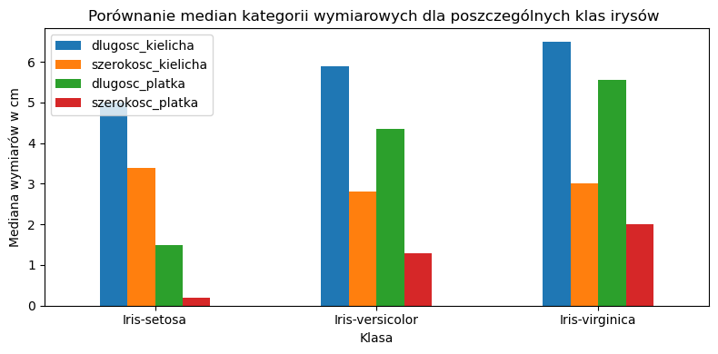

```python
# Wykres słupkowy dla median wymiarów w poszczególnych klasach Irysów

median_values = df.groupby('klasa').median()

median_values.plot(kind='bar', figsize=(8,4))

plt.title('Porównanie median kategorii wymiarowych dla poszczególnych klas irysów ')
plt.xlabel('Klasa')
plt.ylabel('Mediana wymiarów w cm')
plt.xticks(rotation=0)
plt.tight_layout()
plt.show()
```

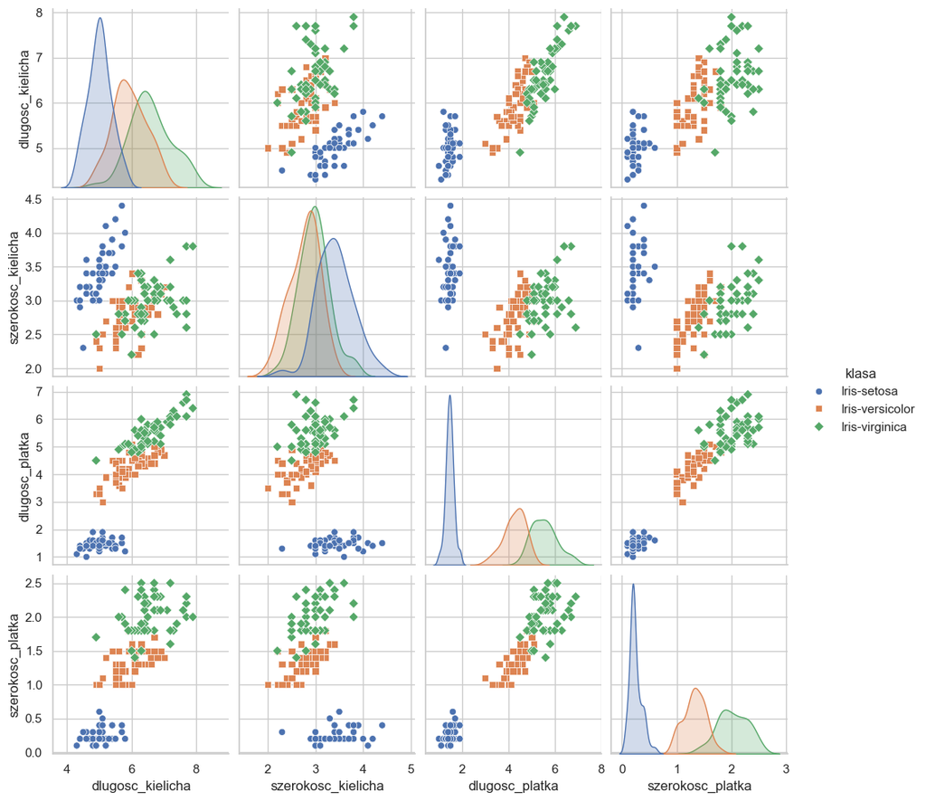

```python
# Analiza spójności parametrów kategorii wymiarowych, oraz wzajemnych relacji poszczególnych wymiarów
# z uwzglednieniem klas gatunkowych

sns.set(style="whitegrid")
pairplot = sns.pairplot(df, hue='klasa', markers=["o", "s", "D"])
pairplot.savefig("iris_scatter_plot.png")
```

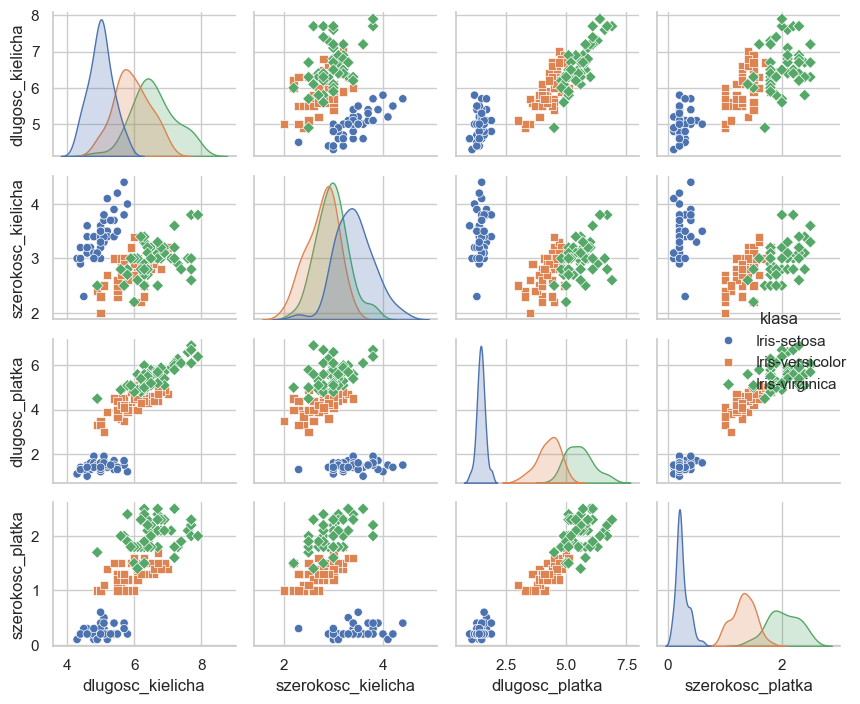

```python
import seaborn as sns
import matplotlib.pyplot as plt

sns.set(style="whitegrid")

# 🔧 mniejszy i bardziej kompaktowy wykres (idealny na slajd)
pairplot = sns.pairplot(
    df,
    hue='klasa',
    markers=["o", "s", "D"],
    height=1.8,         # domyślnie ~2.5 → 1.8 to mniejszy i czytelny format
    aspect=1,           # zachowuje proporcje
)

# 🔍 lepsze dopasowanie marginesów
plt.tight_layout()

# 💾 zapis w dobrej jakości, ale mały rozmiar fizyczny
pairplot.savefig("iris_scatter_plot_small.png", dpi=200, bbox_inches='tight')

plt.show()
```

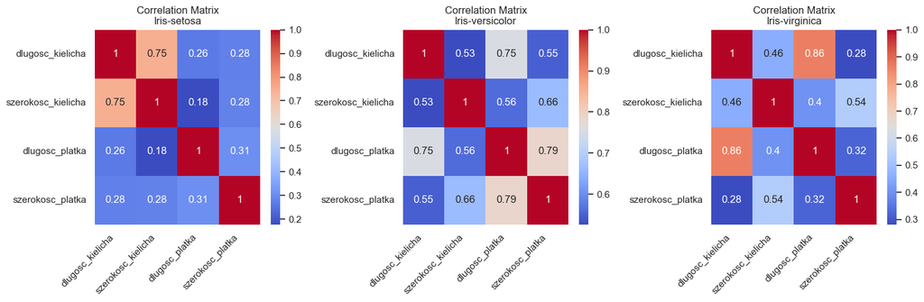

```python
# Korelacja między wielkością kielicha a wielkością płatka dla poszczególnych klas Irysów
# Matryce korelacji

correlation_matrices = []
unique_klasa = df['klasa'].unique()

for iris_klasa in unique_klasa:
    klasa_df = df[df['klasa'] == iris_klasa]
    correlation_matrix = klasa_df.drop(columns='klasa').corr()
    correlation_matrices.append((iris_klasa, correlation_matrix))

fig, axes = plt.subplots(1, len(unique_klasa), figsize=(15, 5))

for ax, (iris_klasa, correlation_matrix) in zip(axes, correlation_matrices):
    sns.heatmap(correlation_matrix, annot=True, cmap='coolwarm', ax=ax)
    ax.set_title(f'Correlation Matrix\n{iris_klasa}')
    ax.set_xticklabels(ax.get_xticklabels(), rotation=45, horizontalalignment='right')
    ax.set_yticklabels(ax.get_yticklabels(), rotation=0)

plt.tight_layout()
plt.savefig('correlation_matrices.png')
```

# 5. Wartości odstające

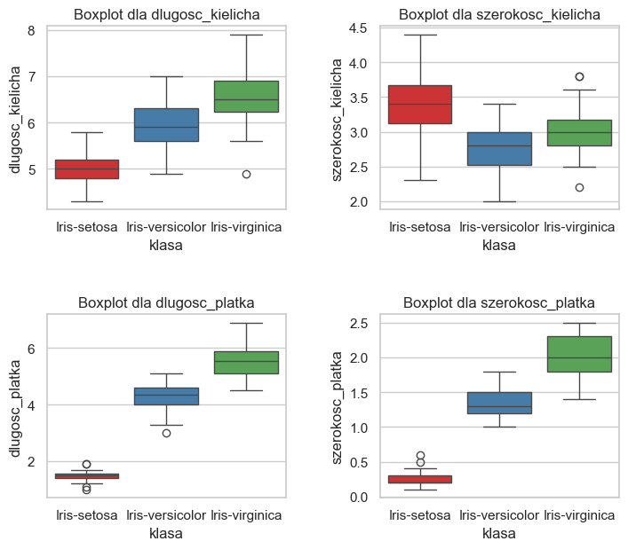

```python
# Box plot - ogólna charakterystyka parametrów z uwzględnieniem wartości odstających

features = ['dlugosc_kielicha', 'szerokosc_kielicha',
            'dlugosc_platka', 'szerokosc_platka']

sns.set_palette("Set1")

fig, axes = plt.subplots(nrows=2, ncols=2, figsize=(8, 7))
axes = axes.flatten()

for i, feature in enumerate(features):
    ax = axes[i]
    sns.boxplot(data=df, x='klasa', y=feature, ax=ax, hue='klasa', palette='Set1')
    ax.set_xlabel('klasa')
    ax.set_ylabel(feature)
    ax.set_title(f'Boxplot dla {feature}')

plt.tight_layout(pad=3.0)
plt.show()
```

## WNIOSKI

wartości odstające nie wystepują wogóle, lub w niewielkim zakresie : najwięcej w długości i szerokości płatka dla Iris-stetosa

# 6. Podsumowanie

1. Dane : dobrej jakości bez braków - 150 próbek 3 klas kwiatów Irysa
2. Klasy kwiatów - parametry :
   - Iris-virginica : największe kwiaty - średnia szerokość kielicha , najwieksze płatki
   - Iris-versicolor : średniej wielkości płatki, najwęższy kielich o średniej wysokości
   - Iris-stetosa : najszerszy i najkrótszy kielich, najmniejsze platki
3. Iris-virginica , oraz Iris-versicolor sa zbliżone wielkością oraz relacjami między kielichami, a płatkami
4. Iris-stetosa najbardzie sie wyróznia z 3 klas swoimi proporcjami szerokość do wysokości kielicha, oraz najmniejsze płatki